# ¿Existe algún comportamiento espacial en la distribución de SARS COV-2 en las colonias de la ciudad de México?

En este ejercicio usaremos los datos de "Casos activos de Covid-19 en Ciudad de México a nivel colonia" actualizada al 15 de Enero de 2021, los cuales registran: 29,339 casos confirmados de SARS COV-2, sin embargo, 5 533 casos no cuentan con un componente espacial, por lo que se desconoce la ubicación de estos.

Uno podría pensar que la distribución de casos de SARS COV-2 en la ciudad de México, sigue un cierto patrón espacial, es decir, que los casos de esta enfermedad se podrían concentrar o ver reducidos en cierta partes de la ciudad. Con esta hipotesis, se propone analizar, de forma sencilla, la espacialidad que podría tener la presencia de esta enfermedad. Esto a través del análisis de la autocorrelación espacial, tanto global como local, del número total de casos activos confirmados a el 15 de Enero de 2021. Para este analisis haremos uso del Índice de Morán, que se forma sencilla no sayuda a identificar si existe un patrón espacial en la distribución general de la variable analizada. Mientras que para una análisis más local, se hará uso de los estadísticos LISA para determinar si existen la presencia de hotspots o coldspost de la enfermedad en la ciudad de México.

Fuente: https://datos.cdmx.gob.mx/explore/dataset/covid-19-sinave-ciudad-de-mexico-a-nivel-colonia/information/?disjunctive.colonia

```python
%matplotlib inline

import seaborn as sns
import pandas as pd
import esda
from pysal.lib import weights
from pysal.viz import mapclassify
from splot.esda import moran_scatterplot, lisa_cluster, plot_local_autocorrelation
import geopandas as gpd
import numpy as np
import contextily as ctx
import matplotlib.pyplot as plt
```

```python
# Cargamos los poligonos
col = gpd.read_file("data/covid-19-sinave-ciudad-de-mexico-a-nivel-colonia.geojson")
# Mostramos la información de la tabla
col.info()
```

```
<class 'geopandas.geodataframe.GeoDataFrame'>
RangeIndex: 1072 entries, 0 to 1071
Data columns (total 9 columns):
 #   Column       Non-Null Count  Dtype
---  ------       --------------  -----
 0   nueva_clave  1072 non-null   object
 1   total        1072 non-null   int64
 2   colonia      1072 non-null   object
 3   alcaldia     1072 non-null   object
 4   decil        1072 non-null   int64
 5   octil        1072 non-null   int64
 6   cuartil      1072 non-null   int64
 7   quintil      1072 non-null   int64
 8   geometry     1069 non-null   geometry
dtypes: geometry(1), int64(5), object(3)
memory usage: 75.5+ KB
```

Con esto podemos apreciar que nuestros datos tienen 1072 filas(entidades) y que cuenta con nueve columnas.  
La información detallada de contiene cada columna se puede encontrar en la pagina de los datos.  
Para este trabajo, ocuparemos las columnas:

- "nueva_clave" - que contienen la clave de colonia, total que nos indica el número total de casos confirmados,
- "colonia" - que proporciona el nombre de la colonia
- "geometry"- que contiene la información geoespacial (poligono de la colonia)

```python
# Damos como indice la columna nueva_clave
col = col.set_index("nueva_clave", drop=False)
# Visualizamos la tabla
col.head()
```

| nueva_clave | nueva_clave | total | colonia | alcaldia | decil | octil | cuartil | quintil | geometry |
| --- | --- | --- | --- | --- | --- | --- | --- | --- | --- |
| 16-012 | 16-012 | 8 | ANGEL ZIMBRON | MIGUEL HIDALGO | 2 | 2 | 1 | 1 | POLYGON ((-99.19060 19.46317, -99.19073 19.464... |
| 16-024 | 16-024 | 15 | DANIEL GARZA | MIGUEL HIDALGO | 5 | 4 | 2 | 3 | POLYGON ((-99.19789 19.40871, -99.19789 19.407... |
| 16-052 | 16-052 | 16 | MODELO PENSIL | MIGUEL HIDALGO | 5 | 4 | 2 | 3 | POLYGON ((-99.19113 19.44840, -99.19067 19.448... |
| 02-023 | 02-023 | 20 | EL ROSARIO A (U HAB) | AZCAPOTZALCO | 6 | 5 | 3 | 3 | POLYGON ((-99.20941 19.50886, -99.21091 19.509... |
| 02-026 | 02-026 | 6 | EUZKADI | AZCAPOTZALCO | 1 | 1 | 1 | 1 | POLYGON ((-99.16543 19.47730, -99.16557 19.477... |

Al ver la tabla apreciamos la forma que tienen nuestro datos, y resaltan algunos que no son de interes para este ejercicio, por lo que necesitamos removerlas de nuetsra tabla

```python
# Eliminamos las columnas que no son de interes
# seleccionamos solo las columnas de interes
col = col.drop(columns=['decil', 'octil', 'cuartil', 'quintil'])
# Visualizamos los cambios
col.head()
```

| nueva_clave | nueva_clave | total | colonia | alcaldia | geometry |
| --- | --- | --- | --- | --- | --- |
| 16-012 | 16-012 | 8 | ANGEL ZIMBRON | MIGUEL HIDALGO | POLYGON ((-99.19060 19.46317, -99.19073 19.464... |
| 16-024 | 16-024 | 15 | DANIEL GARZA | MIGUEL HIDALGO | POLYGON ((-99.19789 19.40871, -99.19789 19.407... |
| 16-052 | 16-052 | 16 | MODELO PENSIL | MIGUEL HIDALGO | POLYGON ((-99.19113 19.44840, -99.19067 19.448... |
| 02-023 | 02-023 | 20 | EL ROSARIO A (U HAB) | AZCAPOTZALCO | POLYGON ((-99.20941 19.50886, -99.21091 19.509... |
| 02-026 | 02-026 | 6 | EUZKADI | AZCAPOTZALCO | POLYGON ((-99.16543 19.47730, -99.16557 19.477... |

Ya que eliminamos la información que no es necesaria procesamos a un poco de limpieza o verificación de nuestros datos  
Procedamos identificar si existen filas sin información en nuestra tabla.

```python
# Contamos el número de valores nulos en cada columna
print(" \nConteo de valores nulos en el dataframe : \n\n",
      col.isnull().sum())
```

```
Conteo de valores nulos en el dataframe :

 nueva_clave    0
total          0
colonia        0
alcaldia       0
geometry       3
dtype: int64
```

Como podemos apreciar, la tabla cuenta con tres valores nulos, esto en la columna de geometría, lo que podría ser especialmente problemático al momento de realizar las carridas de los calculos para obtener los estadísticos de interes, por lo que necesitamos removerlos para así evitar estos conflictos

```python
# Recreamos el df solo con aquellas geometrías que sean poligonos
col = col[col.geometry.type == 'Polygon']

# Confirmamos recontando los valores nulos
print(" \nConteo de valores nulos en el dataframe : \n\n",
      col.isnull().sum())
```

```
Conteo de valores nulos en el dataframe :

 nueva_clave    0
total          0
colonia        0
alcaldia       0
geometry       0
dtype: int64
```

Cuando trabajamos con matrices de pesos espaciales es conveniente que nuestros datos se encuentren en un sistema de coordenadas proyectado,  
es decir, que las unidades del mapa no se encuentre en grados, por lo que necesitamos cerificar el sistema de coordenadas de nuestro archivo y en caso necesario, re proyectarlo

```python
# Checamos el sistema de coordenadas del df
col.crs
```

```
<Geographic 2D CRS: EPSG:4326>
Name: WGS 84
Axis Info [ellipsoidal]:
- Lat[north]: Geodetic latitude (degree)
- Lon[east]: Geodetic longitude (degree)
Area of Use:
- name: World
- bounds: (-180.0, -90.0, 180.0, 90.0)
Datum: World Geodetic System 1984
- Ellipsoid: WGS 84
- Prime Meridian: Greenwich
```

El archivo se encuentra en EPSG 4326, un sistema de coordenadas geográficas, por lo que necesitamos proyectarlo

```python
# reporyactamos el df al epsg 32614, que corresponde a la zona utm 14n
col = col.to_crs(epsg=32614)
# Comprobamos la acción anterior
col.crs
```

```
<Projected CRS: EPSG:32614>
Name: WGS 84 / UTM zone 14N
Axis Info [cartesian]:
- E[east]: Easting (metre)
- N[north]: Northing (metre)
Area of Use:
- name: World - N hemisphere - 102°W to 96°W - by country
- bounds: (-102.0, 0.0, -96.0, 84.0)
Coordinate Operation:
- name: UTM zone 14N
- method: Transverse Mercator
Datum: World Geodetic System 1984
- Ellipsoid: WGS 84
- Prime Meridian: Greenwich
```

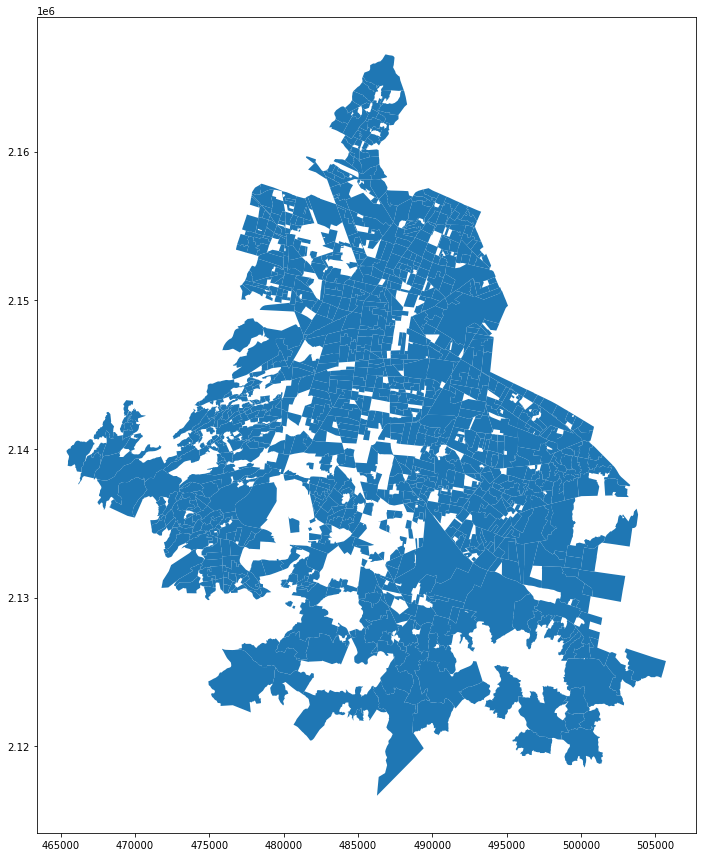

```python
# Visualizamos geometría
col.plot(figsize=(15,15))
```

Como podemos apreciar, en el df existen varios huecos, esto se debe a que la entidad generadora de la información decidio omitir por completo la geometría de aquellas colonias, que cuentan con menos de cinco casos de covid, esto para supuestamente para proteger la confidencialidad de las personas; Ante este problema se tienen dos alternativas:

- Dejar los datos tal y como están
- Colocar esás geometrías faltantas a partir de archivo de colonias original y, asignarle un número de casos menor a 5, el cual puede ser:
  - Un número aleatorio entre 0 y 5
  - Colocar 5
  - Colocar un 3, como promedio

Para este ejercicio, asumiremos "la regla nefasta", es decir, elegiremos el peor escenario posible y asumiremos que hay 5 casos en cada una de estás colonias

```python
# Cargamos la capa de colonias completa
col_1 = gpd.read_file("data/coloniascdmx.geojson")
# Visualizamos la información tabular
col_1.info()
```

```
<class 'geopandas.geodataframe.GeoDataFrame'>
RangeIndex: 1811 entries, 0 to 1810
Data columns (total 9 columns):
 #   Column        Non-Null Count  Dtype
---  ------        --------------  -----
 0   entidad       1809 non-null   float64
 1   cve_alc       1811 non-null   int64
 2   alcaldia      1811 non-null   object
 3   secc_com      1132 non-null   object
 4   geo_point_2d  1811 non-null   object
 5   secc_par      1543 non-null   object
 6   nombre        1811 non-null   object
 7   cve_col       1811 non-null   object
 8   geometry      1811 non-null   geometry
dtypes: float64(1), geometry(1), int64(1), object(6)
memory usage: 127.5+ KB
```

```python
# Eliminamos las columnas que no son de interes
col_1 = col_1.drop(columns=['secc_com', 'secc_par', 'entidad', 'cve_alc', 'geo_point_2d'])
# Damos como indice la columna cve_col
col_1 = col_1.set_index("cve_col", drop=False)
# Visualizamos los cambios
col_1.head()
```

| cve_col | alcaldia | nombre | cve_col | geometry |
| --- | --- | --- | --- | --- |
| 16-042 | MIGUEL HIDALGO | LOMAS DE CHAPULTEPEC | 16-042 | POLYGON ((-99.22017 19.42803, -99.22009 19.428... |
| 16-044 | MIGUEL HIDALGO | LOMAS DE REFORMA (LOMAS DE CHAPULTEPEC) | 16-044 | POLYGON ((-99.22967 19.41406, -99.22970 19.413... |
| 16-026 | MIGUEL HIDALGO | DEL BOSQUE (POLANCO) | 16-026 | POLYGON ((-99.20821 19.43282, -99.20813 19.432... |
| 03-135 | COYOACAN | PEDREGAL DE SANTA URSULA I | 03-135 | POLYGON ((-99.14587 19.31979, -99.14579 19.319... |
| 03-128 | COYOACAN | AJUSCO I | 03-128 | POLYGON ((-99.15854 19.33038, -99.15785 19.329... |

```python
col_1.info()
```

```
<class 'geopandas.geodataframe.GeoDataFrame'>
Index: 1811 entries, 16-042 to 17-076
Data columns (total 4 columns):
 #   Column    Non-Null Count  Dtype
---  ------    --------------  -----
 0   alcaldia  1811 non-null   object
 1   nombre    1811 non-null   object
 2   cve_col   1811 non-null   object
 3   geometry  1811 non-null   geometry
dtypes: geometry(1), object(3)
memory usage: 70.7+ KB
```

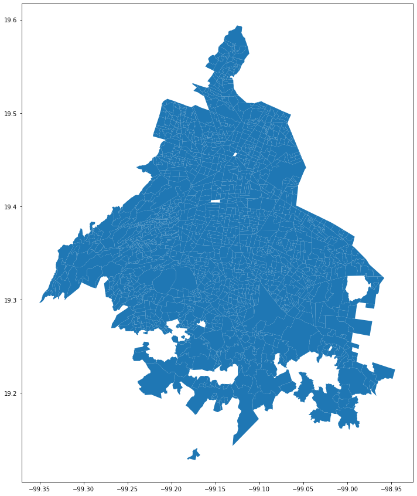

```python
# Visualizamos la geometría
col_1.plot(figsize=(15, 15))
```

```python
# Contamos el número de valores nulos en cada columna
print(" \nConteo de valores nulos en el dataframe : \n\n",
      col_1.isnull().sum())
```

```
Conteo de valores nulos en el dataframe :

 alcaldia    0
nombre      0
cve_col     0
geometry    0
dtype: int64
```

```python
# Reproyectamos el sistema de coordenadas
# reporyactamos el df al epsg 32614, que corresponde a la zona utm 14n
col_1 = col_1.to_crs(epsg=32614)
# Comprobamos la acción anterior
col_1.crs
```

```
<Projected CRS: EPSG:32614>
Name: WGS 84 / UTM zone 14N
Axis Info [cartesian]:
- E[east]: Easting (metre)
- N[north]: Northing (metre)
Area of Use:
- name: World - N hemisphere - 102°W to 96°W - by country
- bounds: (-102.0, 0.0, -96.0, 84.0)
Coordinate Operation:
- name: UTM zone 14N
- method: Transverse Mercator
Datum: World Geodetic System 1984
- Ellipsoid: WGS 84
- Prime Meridian: Greenwich
```

```python
# Creamos la columna que tiene el total de enfermos
col_1['total_'] = 5
```

```python
# Se realiza la unión entre lod df
col2 = pd.merge(col_1, col, left_index=True, right_index=True, how="outer")
col2.info()
```

```
<class 'geopandas.geodataframe.GeoDataFrame'>
Index: 1811 entries, 02-001 to 17-086
Data columns (total 10 columns):
 #   Column       Non-Null Count  Dtype
---  ------       --------------  -----
 0   alcaldia_x   1811 non-null   object
 1   nombre       1811 non-null   object
 2   cve_col      1811 non-null   object
 3   geometry_x   1811 non-null   geometry
 4   total_       1811 non-null   int64
 5   nueva_clave  1068 non-null   object
 6   total        1068 non-null   float64
 7   colonia      1068 non-null   object
 8   alcaldia_y   1068 non-null   object
 9   geometry_y   1068 non-null   geometry
dtypes: float64(1), geometry(2), int64(1), object(6)
memory usage: 155.6+ KB
```

```python
# Contamos el número de valores nulos en cada columna
print(" \nConteo de valores nulos en el dataframe : \n\n",
      col2.isnull().sum())
```

```
Conteo de valores nulos en el dataframe :

 alcaldia_x       0
nombre           0
cve_col          0
geometry_x       0
total_           0
nueva_clave    743
total          743
colonia        743
alcaldia_y     743
geometry_y     743
dtype: int64
```

Como podemos apreciar, se tiene un gran número de entidades con valores nulos, por lo que necesitamos imputar los valores desde las columnas que si lo tienen

```python
# Removamos algunas columnas que no son necesarias
col2 = col2.drop(columns=['alcaldia_y', 'colonia', 'nueva_clave', 'geometry_y'])
col2.head()
```

|  | alcaldia_x | nombre | cve_col | geometry_x | total_ | total |
| --- | --- | --- | --- | --- | --- | --- |
| 02-001 | AZCAPOTZALCO | AGUILERA | 02-001 | POLYGON ((483311.618 2153254.848, 483332.006 2... | 5 | 7.0 |
| 02-002 | AZCAPOTZALCO | ALDANA | 02-002 | POLYGON ((484406.956 2153012.331, 484401.132 2... | 5 | NaN |
| 02-003 | AZCAPOTZALCO | AMPLIACION PETROLERA | 02-003 | POLYGON ((479361.336 2154537.765, 479378.533 2... | 5 | 6.0 |
| 02-005 | AZCAPOTZALCO | ANGEL ZIMBRON | 02-005 | POLYGON ((480013.755 2153003.618, 480026.649 2... | 5 | 8.0 |
| 02-006 | AZCAPOTZALCO | ARENAL | 02-006 | POLYGON ((484061.118 2152622.284, 484061.678 2... | 5 | NaN |

```python
# Rellenamos los valores nulos con el valor de la fila correspondiente de la columna total_, aquella que rellenamos con el valor de 5
col2['total'] = col2['total'].replace(np.nan, col2['total_'])
# Contamos el número de valores nulos en cada columna
print(" \nConteo de valores nulos en el dataframe : \n\n",
      col2.isnull().sum())
```

```
Conteo de valores nulos en el dataframe :

 alcaldia_x    0
nombre        0
cve_col       0
geometry_x    0
total_        0
total         0
dtype: int64
```

```python
# Creamos la nueva columna de geometria
col2['geometry'] = col2['geometry_x']
# Removemos columnas que no son de interes
col2 = col2.drop(columns=['geometry_x', 'total_'])
col2.head()
```

|  | alcaldia_x | nombre | cve_col | total | geometry |
| --- | --- | --- | --- | --- | --- |
| 02-001 | AZCAPOTZALCO | AGUILERA | 02-001 | 7.0 | POLYGON ((483311.618 2153254.848, 483332.006 2... |
| 02-002 | AZCAPOTZALCO | ALDANA | 02-002 | 5.0 | POLYGON ((484406.956 2153012.331, 484401.132 2... |
| 02-003 | AZCAPOTZALCO | AMPLIACION PETROLERA | 02-003 | 6.0 | POLYGON ((479361.336 2154537.765, 479378.533 2... |
| 02-005 | AZCAPOTZALCO | ANGEL ZIMBRON | 02-005 | 8.0 | POLYGON ((480013.755 2153003.618, 480026.649 2... |
| 02-006 | AZCAPOTZALCO | ARENAL | 02-006 | 5.0 | POLYGON ((484061.118 2152622.284, 484061.678 2... |

```python
# Removemos valores duplicados dentro de la columna cve_col
col2 = col2.drop_duplicates(subset=['cve_col'])
col2.info()
```

```
<class 'geopandas.geodataframe.GeoDataFrame'>
Index: 1808 entries, 02-001 to 17-086
Data columns (total 5 columns):
 #   Column      Non-Null Count  Dtype
---  ------      --------------  -----
 0   alcaldia_x  1808 non-null   object
 1   nombre      1808 non-null   object
 2   cve_col     1808 non-null   object
 3   total       1808 non-null   float64
 4   geometry    1808 non-null   geometry
dtypes: float64(1), geometry(1), object(3)
memory usage: 84.8+ KB
```

Ahora ya se tiene listo el dataframe, con lo que se puede preseguir a la identificación de los patrones espaciales del SARS - COV2, sin embargo, antes de eso visualicemos la distribución de la enfermedad, así como su comportamiento general en las colonias de la Ciudad de México

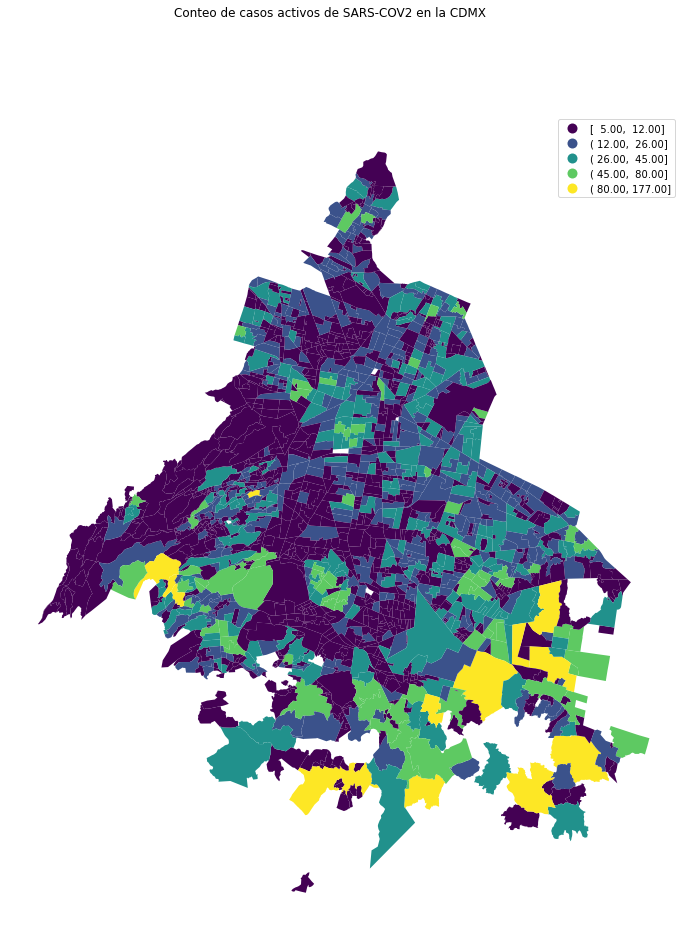

```python
# Setup de la gráfica
f, ax = plt.subplots(1, figsize=(15, 15))
# Agregamos un titulo
f.suptitle("Conteo de casos activos de SARS-COV2 en la CDMX")

# Mostramos y editamos la representación de los elementos a mapear

col2.plot(column="total",
        scheme='fisher_jenks',
        cmap="viridis",
        legend=True,
        ax=ax,) # donde se ubica la información

# Agregamos mapa base
# cx.add_basemap(ax, crs=liv.crs, source=cx.providers.Stamen.Watercolor);
#  Removemos los bordes
ax.set_axis_off()
# Visualizamos
plt.show()
```

```python
# Visualizamos el comportamiento de la variable distribuido en cinco clases
fisher = mapclassify.FisherJenks(col2["total"], k=5)
fisher
```

```
FisherJenks

    Interval       Count
------------------------
[  5.00,  12.00] |  1112
( 12.00,  26.00] |   390
( 26.00,  45.00] |   214
( 45.00,  80.00] |    79
( 80.00, 177.00] |    13
```

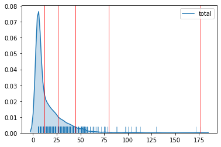

```python
# Preparamos la gráfica
f, ax = plt.subplots(1)
# Graficamos la estimación de densidad kernel (kernel density estimation KDE)
sns.kdeplot(col2["total"], shade=True)
# Add a blue tick for every value at the bottom of the plot (rugs)
sns.rugplot(col2["total"], alpha=0.5)
# Loop sobre cada punto de quiebre (clases) y trazo de línea roja
for cut in fisher.bins:
    plt.axvline(cut, color='red', linewidth=0.75)
# Display image
plt.show()
```

Como podemos apreciar en el mapa y las gráficas subsecuentes, en general y para la fecha correspondiente, al rededor del 60% de las colonias de la ciudad de México presentan un número bastante bajo de casos (de 5 a 12), las cuales se encuentren repartidas en el territorio con cierta homogeneidad, con una clara carga hacia la zona centro y poniente de la ciudad.  
En cuánto a las colonias con el mayor número de casos (de 80 a 177 casos) se encuentran en la zona sur de la ciudad, particularmente en la zona oriente

```python
col = col2
```

Hora de comenzar la distribución espacial de la enfermedad en las colonias de la Ciudad de México

```python
# Creamos la matriz de pesos espaciales
%time w = weights.Queen.from_dataframe(col, idVariable="cve_col")
```

```
Wall time: 934 ms
```

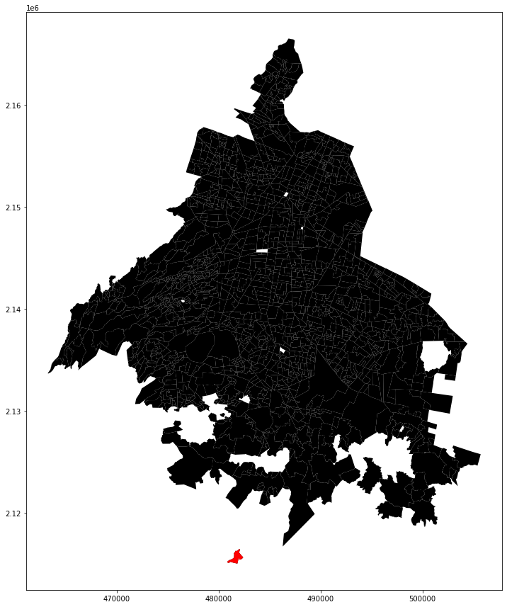

```python
# Mostramos de negro las agebs
ax = col.plot(color='k', figsize=(15, 15))
# Mostramos de rojo las agebs que se encuentran desconectadas
col.loc[w.islands, :].plot(color='red', ax=ax);
```

```python
# Removemos las islas del df
col = col.drop(w.islands)
# Re calculamos la matriz de pesos espaciales
%time w = weights.Queen.from_dataframe(col, idVariable="cve_col")
```

```
Wall time: 1.03 s
```

```python
# Estandarizamos la matriz por fila
%time w.transform = 'R'
```

```
Wall time: 4.01 ms
```

```python
# Crea la versión estandarizada del valor AHAH
col['covid_std'] = (col['total'] - col['total'].mean()) / col['total'].std()
```

```python
# Crea el rezago espacial del valor AHAH
col['covid_lag'] = weights.lag_spatial(w, col['covid_std'])
```

```python
# Visualizamos el dataframe
col.head()
```

|  | alcaldia_x | nombre | cve_col | total | geometry | covid_std | covid_lag |
| --- | --- | --- | --- | --- | --- | --- | --- |
| 02-001 | AZCAPOTZALCO | AGUILERA | 02-001 | 7.0 | POLYGON ((483311.618 2153254.848, 483332.006 2... | -0.509063 | -0.498725 |
| 02-002 | AZCAPOTZALCO | ALDANA | 02-002 | 5.0 | POLYGON ((484406.956 2153012.331, 484401.132 2... | -0.633120 | -0.633120 |
| 02-003 | AZCAPOTZALCO | AMPLIACION PETROLERA | 02-003 | 6.0 | POLYGON ((479361.336 2154537.765, 479378.533 2... | -0.571092 | -0.405683 |
| 02-005 | AZCAPOTZALCO | ANGEL ZIMBRON | 02-005 | 8.0 | POLYGON ((480013.755 2153003.618, 480026.649 2... | -0.447035 | -0.012838 |
| 02-006 | AZCAPOTZALCO | ARENAL | 02-006 | 5.0 | POLYGON ((484061.118 2152622.284, 484061.678 2... | -0.633120 | -0.333317 |

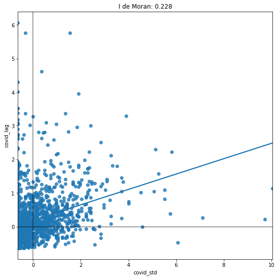

```python
# Setup the figure and axis
f, ax = plt.subplots(1, figsize=(9, 9))
# Plot values
sns.regplot(x='covid_std', y='covid_lag', data=col, ci=None)
# Add vertical and horizontal lines
plt.axvline(0, c='k', alpha=0.5)
plt.axhline(0, c='k', alpha=0.5)
#
ax.set_title("I de Moran: 0.228 ")
# Display
plt.show()
```

```python
# Calculamos la I de Moran a partir de la variabla ahah y la matriz de pesos
mi = esda.Moran(col['total'], w)
print ("I de Moran: ")
print(mi.I)
print(f"P-value: {mi.p_sim}, or {mi.p_sim*100} percent.")
```

```
I de Moran:
0.2285221122478355
P-value: 0.001, or 0.1 percent.
```

```python
# Calculamos los estadísticos LISA a partir de la variable y la matriz de pesos, guardamos estos en una variable los cuales pueden ser accesados
# https://pysal.org/esda/generated/esda.Moran_Local.html
lisa = esda.Moran_Local(col['total'], w)

# Guardamos los valores de la I de Moran en el dataframe
col['i_moran'] = lisa.Is

# Obtenemos los valores de significancia estadistica de cada una de las entidades
col['p_value'] = lisa.p_sim

# Guardamos el cuadrante en el el que se encuentra el valor de la I de Moran, 1 HH, 2 LH, 3 LL, 4 HL
col['quadrant'] = lisa.q

# Creamos una lista con los valores de los cuadrantes a corregir
quadrant = { 1:"HH",
             2:"LH",
             3:"LL",
             4:"HL"}
# Creamos una nueva columna en la que mapeamos los valores de acuerdo a la variable anterior
col["q_meaning"] = col["quadrant"].map(quadrant)

# Visualizamos
col.head(10)
```

|  | alcaldia_x | nombre | cve_col | total | geometry | covid_std | covid_lag | i_moran | p_value | quadrant | q_meaning |
| --- | --- | --- | --- | --- | --- | --- | --- | --- | --- | --- | --- |
| 02-001 | AZCAPOTZALCO | AGUILERA | 02-001 | 7.0 | POLYGON ((483311.618 2153254.848, 483332.006 2... | -0.509063 | -0.498725 | 0.253883 | 0.062 | 3 | LL |
| 02-002 | AZCAPOTZALCO | ALDANA | 02-002 | 5.0 | POLYGON ((484406.956 2153012.331, 484401.132 2... | -0.633120 | -0.633120 | 0.400841 | 0.011 | 3 | LL |
| 02-003 | AZCAPOTZALCO | AMPLIACION PETROLERA | 02-003 | 6.0 | POLYGON ((479361.336 2154537.765, 479378.533 2... | -0.571092 | -0.405683 | 0.231682 | 0.144 | 3 | LL |
| 02-005 | AZCAPOTZALCO | ANGEL ZIMBRON | 02-005 | 8.0 | POLYGON ((480013.755 2153003.618, 480026.649 2... | -0.447035 | -0.012838 | 0.005739 | 0.432 | 3 | LL |
| 02-006 | AZCAPOTZALCO | ARENAL | 02-006 | 5.0 | POLYGON ((484061.118 2152622.284, 484061.678 2... | -0.633120 | -0.333317 | 0.211030 | 0.214 | 3 | LL |
| 02-007 | AZCAPOTZALCO | CENTRO DE AZCAPOTZALCO | 02-007 | 18.0 | POLYGON ((480104.707 2154525.214, 480118.178 2... | 0.173246 | -0.178247 | -0.030881 | 0.324 | 4 | HL |
| 02-008 | AZCAPOTZALCO | CLAVERIA | 02-008 | 10.0 | POLYGON ((480323.635 2152786.517, 480441.701 2... | -0.322979 | -0.234367 | 0.075696 | 0.304 | 3 | LL |
| 02-009 | AZCAPOTZALCO | COLTONGO | 02-009 | 5.0 | POLYGON ((483634.100 2154667.096, 483950.868 2... | -0.633120 | -0.302303 | 0.191394 | 0.238 | 3 | LL |
| 02-010 | AZCAPOTZALCO | COSMOPOLITA | 02-010 | 5.0 | POLYGON ((482638.513 2153649.014, 482658.154 2... | -0.633120 | -0.560754 | 0.355024 | 0.034 | 3 | LL |
| 02-011 | AZCAPOTZALCO | COSMOPOLITA (AMPL) | 02-011 | 11.0 | POLYGON ((483141.894 2153028.894, 483053.542 2... | -0.260951 | -0.544508 | 0.142090 | 0.023 | 3 | LL |

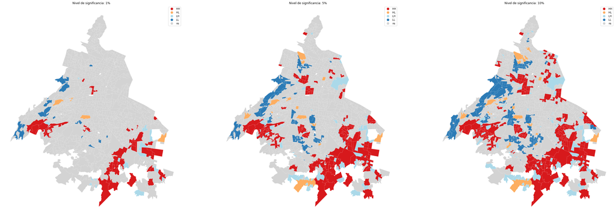

```python
# Crea un mapa de clusters con niveles de significancia del 1% y 10%; comparalos entre entre ellos. ¿Cuáles son los principales cambios? ¿Por qué?
f, axs = plt.subplots(1, 3, figsize=(45, 45))
#
lisa_cluster(lisa, col, p=0.01, ax=axs[0])
axs[0].set_title("Nivel de significancia: 1% ")
#
lisa_cluster(lisa, col, p=0.05, ax=axs[1])
axs[1].set_title("Nivel de significancia: 5%")
#
lisa_cluster(lisa, col, p=0.10, ax=axs[2])
axs[2].set_title("Nivel de significancia: 10%");
```

# Local Indicartors of Spatial Autocorrelation LISA

Respecto a los mapas LISA, se muestran tres resuladados, cada uno con un nivel de significacia distinto (1%, 5% y y 10%) en las que podemos apreciar el comportamiento de la enfermedad respecto a cada colonia y sus vecinos. Dentro de cada una los mapas tenemos una leyenda:

- HH: Valores altos rodeados de valores altos (hotspot).
- HL: Valor alto rodeado de vecinos con valores bajos.
- LH: Valor bajo rodeado de valores altos.
- LL: Valores bajos rodeados de valores bajos (coldspots).

Con esta leyenda y el correspondiente valor de significancia, se puede identificar aquellas colonias en que la probabilidad que existe un patrón espacial sea muy alta, ya sea Hotspots (HH) o coldspots(LL) o alguna colonia con un comportamiento distinto al que tienen sus vecinos (HL o LH). El mapa com un mivel de significancia del 1% (99% de probabilidad) es particularmente util, ya que nos permite identificar aquellas colonias en las que efectivamente hay un comportamiento espacial, en el podemos apreciar que hay grandes concentraciones de un alto número de casos en la zona sur de la ciudad, particularmente en la zona oriente. De igual manera se puden encontrar otras concentraciones de valores altos en el territorio, sin embargo, estos presentan un tamaño menor, esto en la zona poniente de la ciudad, centro/sur y finalmente en el centro de la ciudad. Otro patrón de particular interes es la presencia de coldspots, zonas de valores bajos rodeadas de vecinos con un valor similar, esto predominantemente en la zona poniente de la ciudad. Al aumentar los niveles de significancia, ya sea al 5% 0 al 10%, auque este ultimo no es tan recomendable debido al incremento considerable de incertidumbre respecto al proceso espacial que esta visualizando, se puede apreciar un incremento considerable de los patrones de concentración, los cuales se ubican de forma concentrica a las colonias vistas en el nivel de significancia inferior.

El uso de estos estádisticos y su representación espacial es particularmente util, ya que permite la identificación de aquellas zonas en las que existe un comportamiento disimilar a lo que esta pasando en la gran mayoría del territorio, permitiendo una mejor planeación en la forma en que se desarrollan los fenomenos, en este caso la propagación del SARS-COV2, lo que posiblemente podría permitir una mejor mejor contención, actuando sobre las colonias que se estan dando casos de propagación.